# Polynomial_Regression

### Predictions based on the fitted model

```r
hprange<-range(mtcars$hp)
hp_grid<-seq(from=hprange[1],to=hprange[2])
predicted_mileage<-predict(model1,newdata=list(hp=hp_grid))
```

Let’s plot these predicted values on the graph.

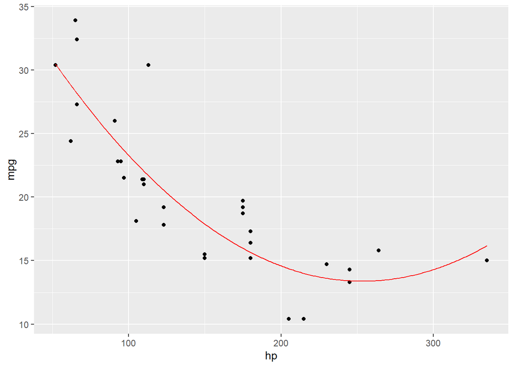

```r
library(ggplot2)
ggplot()+
  geom_point(aes(x = hp, y = mpg),data=mtcars,color="black")+
  geom_line(aes(x = hp_grid,y=predicted_mileage), color = "red")
```

Let’s now consider another models with cubic and another with fourth order terms and compare them for any significant difference.

```r
model2<-lm(mpg~poly(hp,3,raw=T),data=mtcars)
model3<-lm(mpg~poly(hp,4,raw=T),data=mtcars)
model0<-lm(mpg~hp,data=mtcars)
anova(model0,model1,model2,model3)
```

```
## Analysis of Variance Table
##
## Model 1: mpg ~ hp
## Model 2: mpg ~ poly(hp, 2, raw = TRUE)
## Model 3: mpg ~ poly(hp, 3, raw = T)
## Model 4: mpg ~ poly(hp, 4, raw = T)
##   Res.Df    RSS Df Sum of Sq       F    Pr(>F)
## 1     30 447.67
## 2     29 274.63  1   173.043 17.3352 0.0002868 ***
## 3     28 269.61  1     5.026  0.5035 0.4840465
## 4     27 269.52  1     0.087  0.0088 0.9261317
## ---
## Signif. codes:  0 '***' 0.001 '**' 0.01 '*' 0.05 '.' 0.1 ' ' 1
```

If $p-value<\alpha$ it supports the hypothesis that models are statistically different and higher order terms are required. We observe that in our case the linear model and quadratic models are statistically different so, there is a need to use the quadratic model. But moving from quadratic to cubic is not necessary. Therefore, there is no significant advantage in using a model with more cubic or higher order terms.

# Splines

Next, we introduce the notion of regression splines. These models divide the range of $x$ into regions and fit seperate polynomial regression models to each region. While polynomials are “global” (changing a point on one end affects the whole curve), splines are “local”—they use different pieces of curves joined at points called knots.

Instead of `poly(hp, 2)`, we use `bs(hp, df = ...)`. The df (degrees of freedom) determines how many “knots” or bends the spline has. By default, the `bs()` function uses cubic polynomials (degree 3) for every segment. When you change df, you aren’t changing the power ($x^3$ stays $x^3$); you are changing how many “knots” (joints) are used to connect those cubic segments.

```r
library(splines)
model_spline <- lm(mpg ~ bs(hp, df = 5), data = mtcars)
summary(model_spline)
```

```
##
## Call:
## lm(formula = mpg ~ bs(hp, df = 5), data = mtcars)
##
## Residuals:
##     Min      1Q  Median      3Q     Max
## -5.0551 -1.6748 -0.3748  1.3276  9.4184
##
## Coefficients:
##                 Estimate Std. Error t value Pr(>|t|)
## (Intercept)       30.616      2.804  10.918  3.3e-11 ***
## bs(hp, df = 5)1   -1.791      5.698  -0.314  0.75581
## bs(hp, df = 5)2  -11.435      3.148  -3.633  0.00121 **
## bs(hp, df = 5)3  -15.946      5.556  -2.870  0.00805 **
## bs(hp, df = 5)4  -18.905      5.497  -3.439  0.00198 **
## bs(hp, df = 5)5  -15.258      4.268  -3.575  0.00140 **
## ---
## Signif. codes:  0 '***' 0.001 '**' 0.01 '*' 0.05 '.' 0.1 ' ' 1
##
## Residual standard error: 3.202 on 26 degrees of freedom
## Multiple R-squared:  0.7633, Adjusted R-squared:  0.7178
## F-statistic: 16.77 on 5 and 26 DF,  p-value: 2.04e-07
```

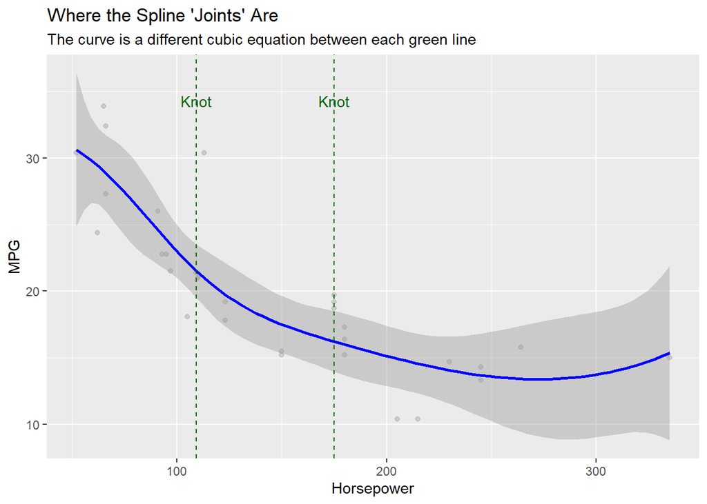

```r
knots <- attr(bs(mtcars$hp, df = 5), "knots")
ggplot(mtcars, aes(x = hp, y = mpg)) +
  geom_point(color = "darkgrey", alpha = 0.5) +
  # The Spline Curve
  stat_smooth(method = "lm", formula = y ~ bs(x, df = 5), color = "blue", size = 1) +
  # Vertical lines representing the "Knots"
  geom_vline(xintercept = knots, linetype = "dashed", color = "darkgreen") +
  annotate("text", x = knots, y = 33, label = "Knot", color = "darkgreen", vjust = -1) +
  labs(title = "Where the Spline 'Joints' Are",
       subtitle = "The curve is a different cubic equation between each green line",
       x = "Horsepower", y = "MPG")
```

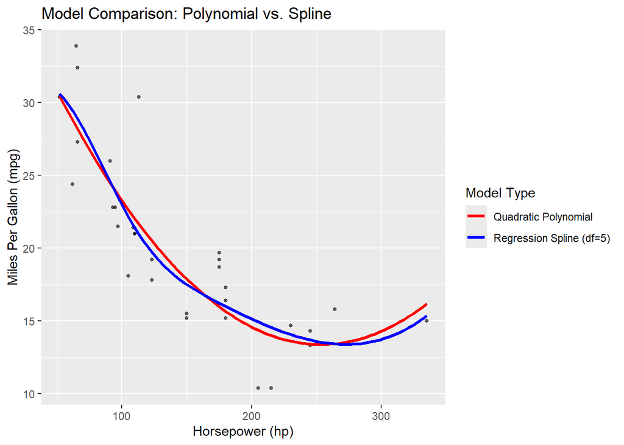

```r
ggplot(mtcars, aes(x = hp, y = mpg)) +
  # 1. The Data Points
  geom_point(color ="black", size = 1, alpha = 0.6) +

  # 2. The Original Quadratic Model (from your first request)
  stat_smooth(method = "lm",
              formula = y ~ poly(x, 2),
              aes(color = "Quadratic Polynomial"),
              se = FALSE, size = 1.2) +

  # 3. The New Regression Spline (Cubic spline, df=3)
  stat_smooth(method = "lm",
              formula = y ~ bs(x, df = 5),
              aes(color = "Regression Spline (df=5)"),
              se = FALSE, size = 1.2) +

  # 4. Customizing colors and labels
  scale_color_manual(name = "Model Type",
                     values = c("Quadratic Polynomial" = "red",
                                "Regression Spline (df=5)" = "blue")) +
  labs(title = "Model Comparison: Polynomial vs. Spline",
       x = "Horsepower (hp)",
       y = "Miles Per Gallon (mpg)")
```

# Fitting GAM

GAMs allow use to findin optimal smoothing, by selecting number of knots. And it also allows us to have other covariates

```r
library(mgcv)
# s(hp) tells R to find the optimal smoothness for horsepower
model_gam <- gam(mpg ~ s(hp), data = mtcars)
summary(model_gam)
```

```
##
## Family: gaussian
## Link function: identity
##
## Formula:
## mpg ~ s(hp)
##
## Parametric coefficients:
##             Estimate Std. Error t value Pr(>|t|)
## (Intercept)  20.0906     0.5487   36.62   <2e-16 ***
## ---
## Signif. codes:  0 '***' 0.001 '**' 0.01 '*' 0.05 '.' 0.1 ' ' 1
##
## Approximate significance of smooth terms:
##         edf Ref.df     F p-value
## s(hp) 2.618  3.263 26.26  <2e-16 ***
## ---
## Signif. codes:  0 '***' 0.001 '**' 0.01 '*' 0.05 '.' 0.1 ' ' 1
##
## R-sq.(adj) =  0.735   Deviance explained = 75.7%
## GCV = 10.862  Scale est. = 9.6335    n = 32
```

The edf value obtained here is `2.618` tell us that the best fit curve is a little more complex than a quadratic but less than a cubic.

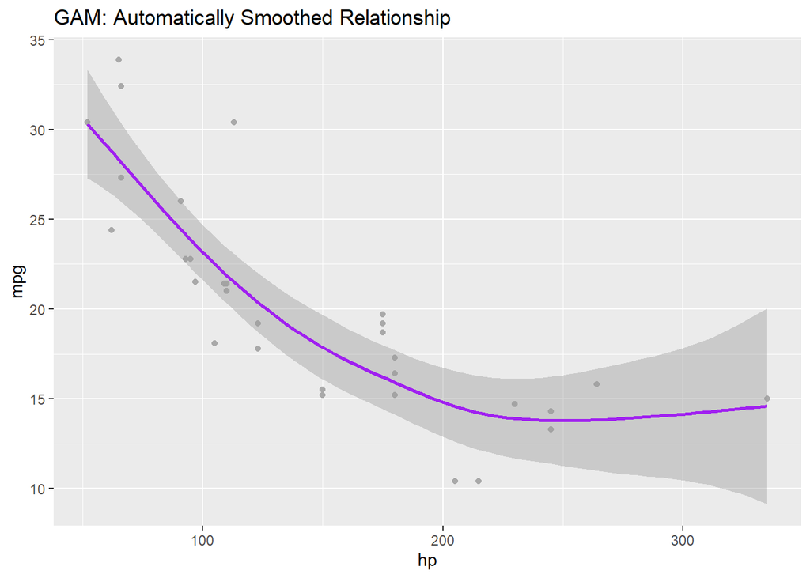

```r
library(ggplot2)

ggplot(mtcars, aes(x = hp, y = mpg)) +
  geom_point(color = "darkgrey", size = 1.5) +
  # method = "gam" uses the mgcv logic automatically
  stat_smooth(method = "gam",
              formula = y ~ s(x),
              color = "purple") +
  labs(title = "GAM: Automatically Smoothed Relationship")
```

## Adding other predictors

```r
library(gam)
```

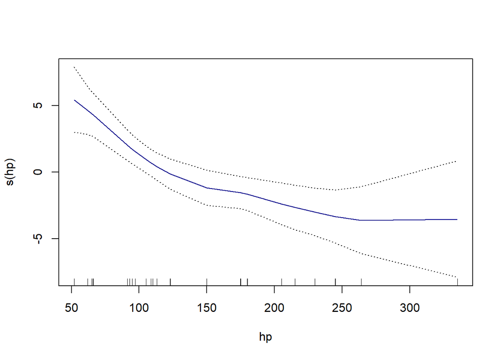

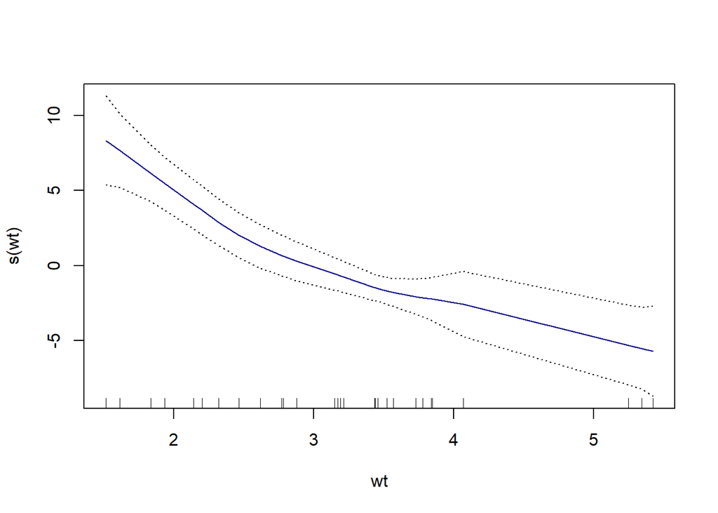

```r
model_gam2 <- gam(mpg ~ s(hp) + s(wt), data = mtcars)
plot.Gam(model_gam2,se=TRUE,col="darkblue")
```

Let’s compare all models.

```r
anova(model1,model_spline,model_gam2)
```

```
## Analysis of Variance Table
##
## Model 1: mpg ~ poly(hp, 2, raw = TRUE)
## Model 2: mpg ~ bs(hp, df = 5)
## Model 3: mpg ~ s(hp) + s(wt)
##   Res.Df    RSS Df Sum of Sq       F    Pr(>F)
## 1     29 274.63
## 2     26 266.52  3     8.107  0.6045    0.6187
## 3     23 102.81  3   163.713 12.2080 5.544e-05 ***
## ---
## Signif. codes:  0 '***' 0.001 '**' 0.01 '*' 0.05 '.' 0.1 ' ' 1
```

The GAM model clearly outperforms both other models.